# Tipos de filme de Robert Downey Jr.

Abaixo foi feito um agrupamento dos filmes de Robert Downey Jr. encontrados no site do Rotten Tomatoes com as avaliações e os valores de bilheteria nos EUA. Abaixo vemos a hierarquia de agrupamentos, onde os filmes e grupos são unidos dois a dois baseando-se nessas duas variáveis.

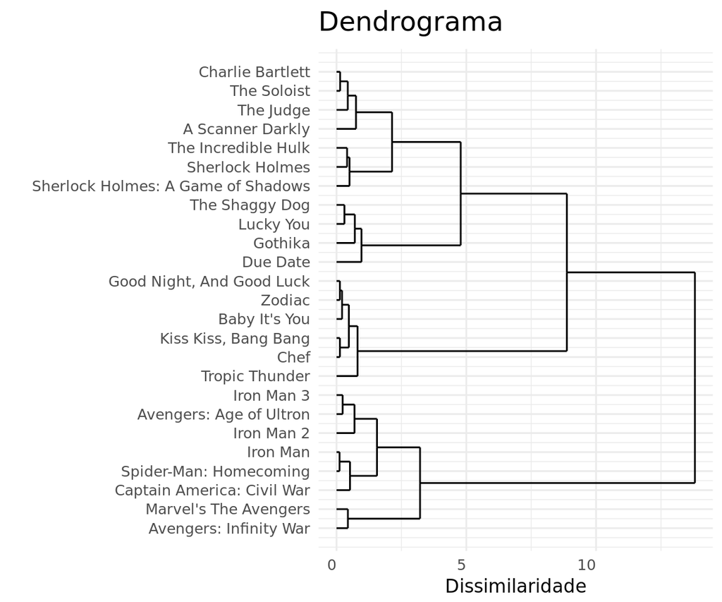

```r
agrupamento_h = filmes %>%
    mutate(nome = paste0(filme, " (av=", avaliacao, ")")) %>%
    mutate_at(vars(avaliacao, bilheteria),
              funs(scale)) %>%
    as.data.frame() %>%
    column_to_rownames("filme") %>%
    select(avaliacao, bilheteria) %>%
    dist(method = "euclidian") %>%
    hclust(method = "ward.D")

ggdendrogram(agrupamento_h, rotate = T, size = 2, theme_dendro = F) +
    labs(y = "Dissimilaridade", x = "", title = "Dendrograma")
```

De cara nós podemos perceber que existem dois grandes grupos de filmes do ator, que pela hierarquia acima, vemos que existe um grupo de Iron Man 3 pra baixo, que é apenas composto por filmes da marvel e de Topic Thunder pra cima que são os filmes “não marvel” (Com exceção do incrível hulk). Abaixo vemos mais facilmente os grupos distribuídos num gráfico de pontos e percebemos que o grande grupo da marvel é composto por filmes de alta avaliação e bilheteria enorme, com a exceção citada anteriormente do incrível hulk, que apesar de ser um filme da marvel, não teve o mesmo sucesso dos seus sucessores. Ainda no grupo da marvel, podemos ver nos dois gráficos que o primeiro filme dos vingadores está isolado com o último (Infinity War), o motivo disso foi a grande espera por esses filmes, ambos são a culminação de eventos que foram acontecendo ao longo de vários filmes anteriores fazendo com que sejam grandes ápices da marvel nos cinemas.

```r
grupos = agrupamento_h %>%
    cutree(4) %>%
    as.data.frame()

nomes_filmes = grupos %>%
    rownames(.)

grupos = grupos %>%
    mutate(filme = nomes_filmes)

colnames(grupos)[1] <- "grupo"

grupos = grupos %>%
    left_join(filmes, by = "filme")

grupos %>%
    plot_ly(x = ~avaliacao, y = ~bilheteria, text = ~paste("Filme: ", filme)) %>%
    add_markers(color = ~grupo) %>%
    layout(yaxis = list(title = "Bilheteria"), xaxis = list(title = "Avaliaçao"))
```

[interactive chart not shown]